# Model exploration

Published

June 5, 2026

## Setup

Load libraries and pre-processed GTM data.

```r
library(here)
library(mgcv)
library(gratia)
library(tidyverse)

load(file = here('data', 'gtmdat.RData'))
```

These plots just show chlorophyll to get a sense of the data and some of the associations.

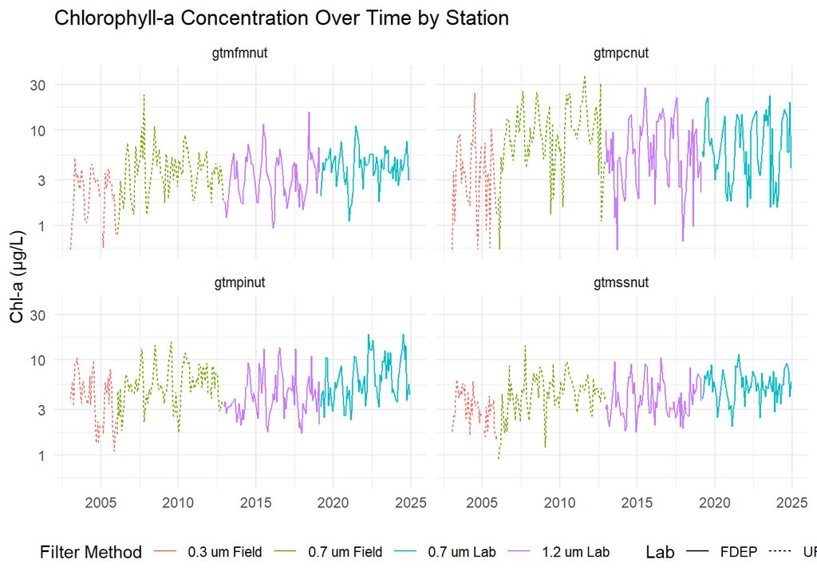

```r
ggplot(gtmdat, aes(x = sample_date, y = value, color = filter_method)) +
  geom_line(aes(linetype = lab)) +
  scale_y_log10() +
  facet_wrap(~ STN_NAME) +
  theme_minimal() +
  theme(legend.position = "bottom") +
  labs(title = "Chlorophyll-a Concentration Over Time by Station",
       x = NULL,
       y = "Chl-a (µg/L)",
       color = "Filter Method",
       linetype = "Lab")
```

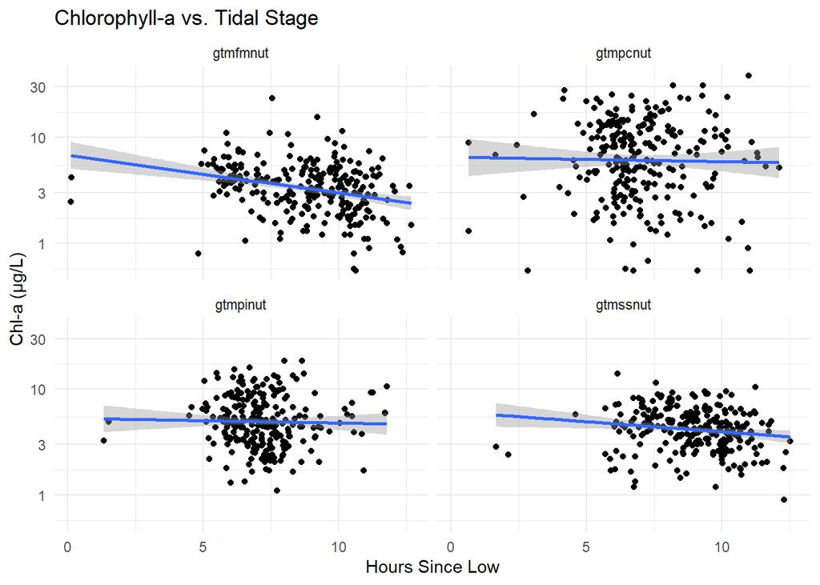

```r
ggplot(gtmdat, aes(x = hours_since_low, y = value)) +
    geom_point() +
    geom_smooth(method = 'lm', formula = y ~ x) +
    facet_wrap(~ STN_NAME) +
    scale_y_log10() +
    theme_minimal() +
    labs(title = "Chlorophyll-a vs. Tidal Stage",
            x = "Hours Since Low",
            y = "Chl-a (µg/L)")
```

## Model

Use model 6 and gtmfmnut for the examples. This station also seems to have the strongest association with tide. We’ll start with the k values from Murphy et al.

```r
sta <- 'gtmfmnut'

dat <- gtmdat |>
  filter(STN_NAME == sta) |>
  filter(!is.na(value))

k_val <- round((2/3) * (max(dat$cont_year) - min(dat$cont_year)))
k_val <- max(k_val, 3)

m6 <- gam(value ~ s(cont_year, by = filter_method, k = k_val) +
          s(hours_since_low, bs = "cc", k = 4) +
          lab +
          filter_method,
      data = dat,
      family = Gamma(link = "log"),
      method = "REML")
```

Quick summary of the model - note the low R-squared and deviance explained.

```r
summary(m6)
```

```
Family: Gamma
Link function: log

Formula:
value ~ s(cont_year, by = filter_method, k = k_val) + s(hours_since_low,
    bs = "cc", k = 4) + lab + filter_method

Parametric coefficients:
                          Estimate Std. Error t value Pr(>|t|)
(Intercept)                 0.3177     1.7235   0.184    0.854
labUF                       0.1545     4.8523   0.032    0.975
filter_method0.7 um Field  -0.1189     4.8997  -0.024    0.981
filter_method0.7 um Lab     0.7140     1.7553   0.407    0.685
filter_method1.2 um Lab     0.0000     0.0000     NaN      NaN

Approximate significance of smooth terms:
                                         edf Ref.df     F  p-value
s(cont_year):filter_method0.3 um Field 1.287  1.497 0.061  0.90237
s(cont_year):filter_method0.7 um Field 3.105  3.734 3.973  0.00349 **
s(cont_year):filter_method0.7 um Lab   1.000  1.001 0.225  0.63556
s(cont_year):filter_method1.2 um Lab   3.220  3.797 1.508  0.14191
s(hours_since_low)                     1.781  2.000 9.387 2.83e-05 ***
---
Signif. codes:  0 '***' 0.001 '**' 0.01 '*' 0.05 '.' 0.1 ' ' 1

Rank: 62/63
R-sq.(adj) =  0.131   Deviance explained = 26.2%
-REML = 503.39  Scale est. = 0.27321   n = 254
```

Run some model diagnostics.

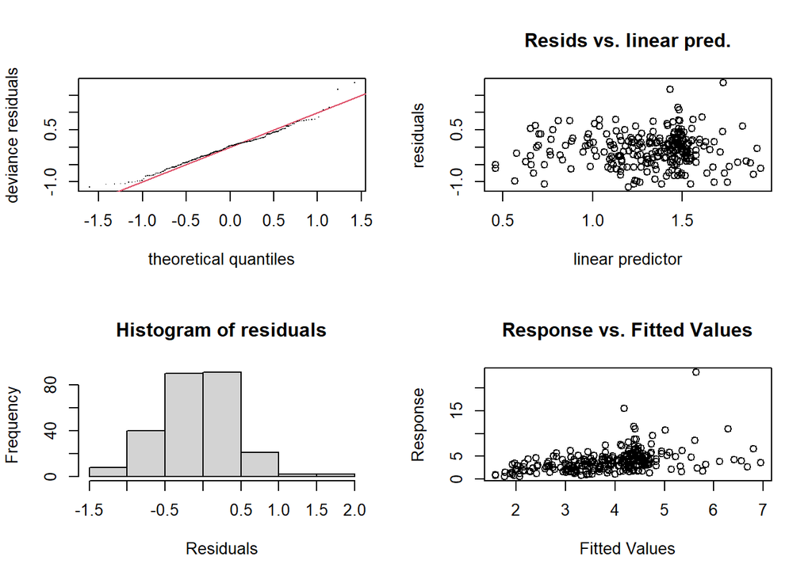

```
Method: REML   Optimizer: outer newton
full convergence after 10 iterations.
Gradient range [-0.0001739588,5.028885e-05]
(score 503.3916 & scale 0.2732076).
Hessian positive definite, eigenvalue range [0.0001739196,132.491].
Model rank =  62 / 63

Basis dimension (k) checking results. Low p-value (k-index<1) may
indicate that k is too low, especially if edf is close to k'.

                                          k'   edf k-index p-value
s(cont_year):filter_method0.3 um Field 14.00  1.29    0.54  <2e-16 ***
s(cont_year):filter_method0.7 um Field 14.00  3.11    0.54  <2e-16 ***
s(cont_year):filter_method0.7 um Lab   14.00  1.00    0.54  <2e-16 ***
s(cont_year):filter_method1.2 um Lab   14.00  3.22    0.54  <2e-16 ***
s(hours_since_low)                      2.00  1.78    0.95    0.28
---
Signif. codes:  0 '***' 0.001 '**' 0.01 '*' 0.05 '.' 0.1 ' ' 1
```

```r
gam.check(m6)
```

I use `gam.check()` to compare `k'` to `edf`. If the values are similar, it often means that the knots are not high enough. That part looks okay, but the `k-index` is very low, suggesting some kind of systematic underfitting.

Looking at a plot of the predictions vs observed confirms this to be the case.

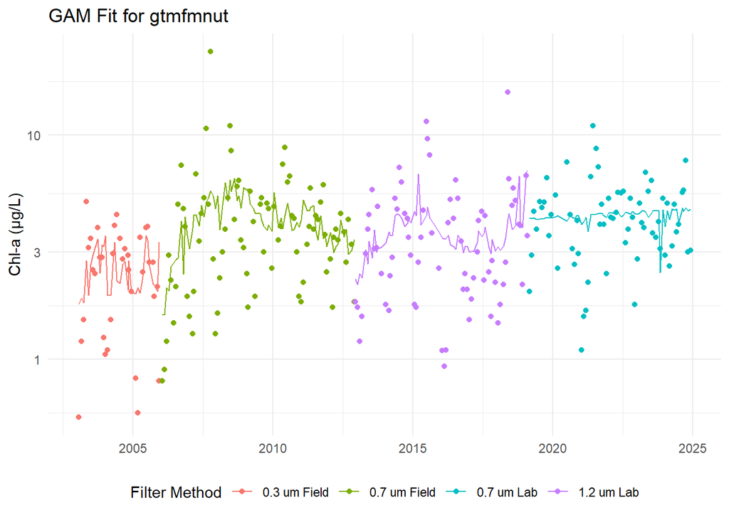

```r
dat <- dat |>
  mutate(prd = predict(m6, type = "response"))

ggplot(dat, aes(x = sample_date, y = value, color = filter_method)) +
  geom_point() +
  geom_line(aes(y = prd)) +
  scale_y_log10() +
  theme_minimal() +
  theme(
    legend.position = "bottom"
  ) +
  labs(title = paste("GAM Fit for", sta),
       x = NULL,
       y = "Chl-a (µg/L)",
       color = "Filter Method")
```

Some of your slides show that you looked at this, but I want to make the point that the Murphy method of choosing k is too conservative for this data. Importantly, they also use a smoother for day of year that captures seasonality. In that case, smaller k values for `cont_year` are fine since it doesn’t need to describe seasonality. This will not work for model 6.

Here I’m using the method from our 2022 paper, downscaling the “month” multiplier just a bit to account for the available degrees of freedom. In practice, small changes in this number shouldn’t matter much, but there should be some justification for why the multiplier was chosen. Our paper uses 12 given monthly sampling, which is probably overkill and can be too high when limited by degrees of freedom (as in this case). Note that the model does take several minutes to fit, so I’m saving it and then loading it later.

```r
k_val <- 10 * length(unique(dat$yr))
m6b <- gam(value ~ s(cont_year, by = filter_method, k = k_val) +
          s(hours_since_low, bs = "cc", k = 4) +
          lab +
          filter_method,
      data = dat,
      family = Gamma(link = "log"),
      method = "REML")
save(m6b, file = here('data', 'm6b.RData'))
```

```r
load(file = here('data', 'm6b.RData'))
```

There’s about a three-fold increase in the R-squared and explained deviance.

```r
summary(m6b)
```

```
Family: Gamma
Link function: log

Formula:
value ~ s(cont_year, by = filter_method, k = k_val) + s(hours_since_low,
    bs = "cc", k = 4) + lab + filter_method

Parametric coefficients:
                          Estimate Std. Error t value Pr(>|t|)
(Intercept)                 -19.86      50.38  -0.394    0.694
labUF                      -163.45     264.48  -0.618    0.537
filter_method0.7 um Field   161.56     266.66   0.606    0.545
filter_method0.7 um Lab       0.00       0.00     NaN      NaN
filter_method1.2 um Lab      23.82      79.73   0.299    0.765

Approximate significance of smooth terms:
                                          edf Ref.df     F p-value
s(cont_year):filter_method0.3 um Field 10.784  13.34 0.125 0.99994
s(cont_year):filter_method0.7 um Field 22.744  28.24 0.080 1.00000
s(cont_year):filter_method0.7 um Lab   12.659  15.77 0.127 0.99999
s(cont_year):filter_method1.2 um Lab   21.806  26.96 0.034 1.00000
s(hours_since_low)                      1.675   2.00 4.850 0.00215 **
---
Signif. codes:  0 '***' 0.001 '**' 0.01 '*' 0.05 '.' 0.1 ' ' 1

Rank: 882/883
R-sq.(adj) =  0.452   Deviance explained = 74.6%
-REML = 475.67  Scale est. = 0.12034   n = 254
```

The model fit to the data looks much better.

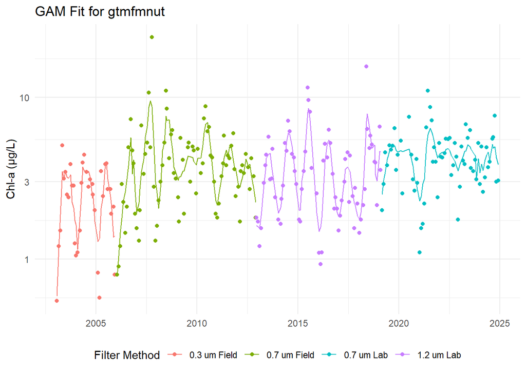

```r
dat <- dat |>
  mutate(prdb = predict(m6b, type = "response"))

ggplot(dat, aes(x = sample_date, y = value, color = filter_method)) +
  geom_point() +
  geom_line(aes(y = prdb)) +
  scale_y_log10() +
  theme_minimal() +
  theme(
    legend.position = "bottom"
  ) +
  labs(title = paste("GAM Fit for", sta),
       x = NULL,
       y = "Chl-a (µg/L)",
       color = "Filter Method")
```

The problem with the `by` argument though is that it only fits a separate smooth for the period of time when the filter method was used. We cannot make any statements about the effect of filter method overall because the effect is specific to only one time slice when that method was used.

The challenge of understanding the filter effects (if that is one of the primary goals) is that they are independent across time, so using a smoother that combines both time and filter could produce a well-fitted model, but you cannot easily evaluate the effects of the filters. Looking at your model 1, this might be the better approach, but include a higher value for k in the `cont_year` smoother.

```r
k_val <- 10 * length(unique(dat$yr))
m1b <- gam(value ~ s(cont_year, k = k_val) +
          s(hours_since_low, bs = "cc", k = 4) +
          filter_method +
          lab,
      data = dat,
      family = Gamma(link = "log"),
      method = "REML")
save(m1b, file = here('data', 'm1b.RData'))
```

```r
load(file = here('data', 'm1b.RData'))
```

Model m1b also has a good predictive fit to the data, similar to m6b, simply by increasing the k values.

```r
summary(m1b)
```

```
Family: Gamma
Link function: log

Formula:
value ~ s(cont_year, k = k_val) + s(hours_since_low, bs = "cc",
    k = 4) + filter_method + lab

Parametric coefficients:
                          Estimate Std. Error t value Pr(>|t|)
(Intercept)                 1.7919     0.5723   3.131  0.00203 **
filter_method0.7 um Field  -0.2673     0.5778  -0.463  0.64414
filter_method0.7 um Lab    -1.2759     0.8865  -1.439  0.15182
filter_method1.2 um Lab    -0.4894     0.7361  -0.665  0.50702
labUF                       0.0000     0.0000     NaN      NaN
---
Signif. codes:  0 '***' 0.001 '**' 0.01 '*' 0.05 '.' 0.1 ' ' 1

Approximate significance of smooth terms:
                     edf Ref.df     F p-value
s(cont_year)       68.12  84.77 3.830 < 2e-16 ***
s(hours_since_low)  1.58   2.00 3.935 0.00411 **
---
Signif. codes:  0 '***' 0.001 '**' 0.01 '*' 0.05 '.' 0.1 ' ' 1

Rank: 225/226
R-sq.(adj) =   0.46   Deviance explained = 74.4%
-REML = 516.19  Scale est. = 0.12154   n = 254
```

Also note that although m6b includes a fixed effect of the filters just like m1b, their additive effects are completely confounded by including them with the `cont_year` smoother. Model m1b retains an effect of the filters that can be disambiguated from time.

## Model slices

Now we can get creative with model `m1b` to look at the predictions under different conditions. These give you an idea of how chlorophyll estimates might change using different filters.

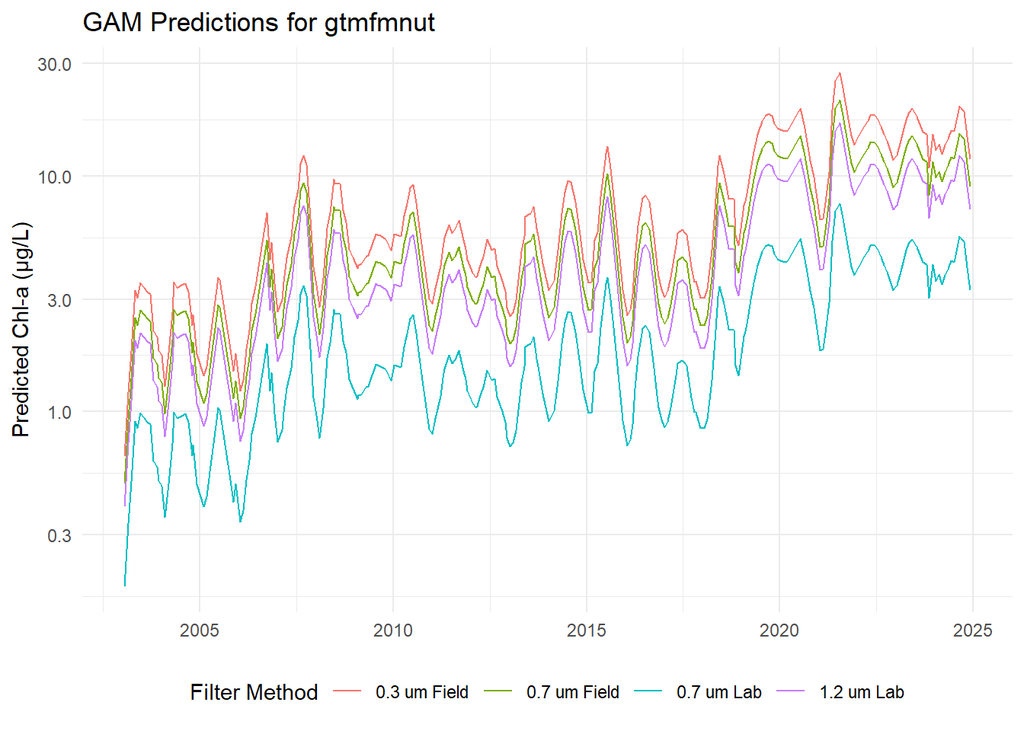

```r
toprd <- dat |>
    select(sample_date, cont_year, hours_since_low, lab) |>
    crossing(
        filter_method = unique(dat$filter_method)
    )

prds <- predict(m1b, newdata = toprd, type = "response")

toplo <- bind_cols(toprd, prds = prds)

ggplot(toplo, aes(x = sample_date, y = prds, group = filter_method,color = filter_method)) +
    geom_line() +
    scale_y_log10() +
    theme_minimal() +
    theme(legend.position = 'bottom') +
    labs(title = paste("GAM Predictions for", sta),
         x = NULL,
         y = "Predicted Chl-a (µg/L)",
         color = "Filter Method")
```

You can also see the magnitude of these effects using some methods from the gratia package, though I think the previous plot is more compelling (understanding it doesn’t capture the uncertainty). In this example, you can see that filter effects are not significant, although it does translate into noticeable differences in the predictions. The summary output above for the model also shows that the filter effects are not significant (parametric coefficients). Same deal for the lab effects.

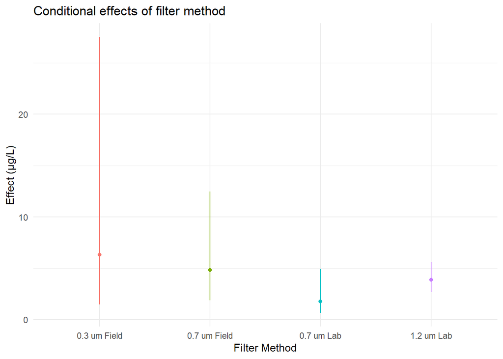

```r
toplo <- conditional_values(m1b, condition = "filter_method")
ggplot(toplo, aes(x = filter_method, y = .fitted, group = filter_method, color = filter_method)) +
    geom_point() +
    geom_errorbar(aes(ymin = .lower_ci, ymax = .upper_ci), width = 0) +
    theme_minimal() +
    theme(legend.position = 'none') +
    labs(title = 'Conditional effects of filter method',
         x = "Filter Method",
         y = "Effect (µg/L)",
         color = "Filter Method")
```

Now what’s more interesting is how you might evaluate the effects of the tide. You can again create a prediction matrix with the range of conditions you want to evaluate. Filter method and lab can also be held constant at one of the levels for each since these are less important (gratia has methods to get these prediction matrices, but I prefer this way). However, as shown later, holding these factors at single values gets messy when you’re evaluating confidence in the predictions, which are not conveyed in this plot.

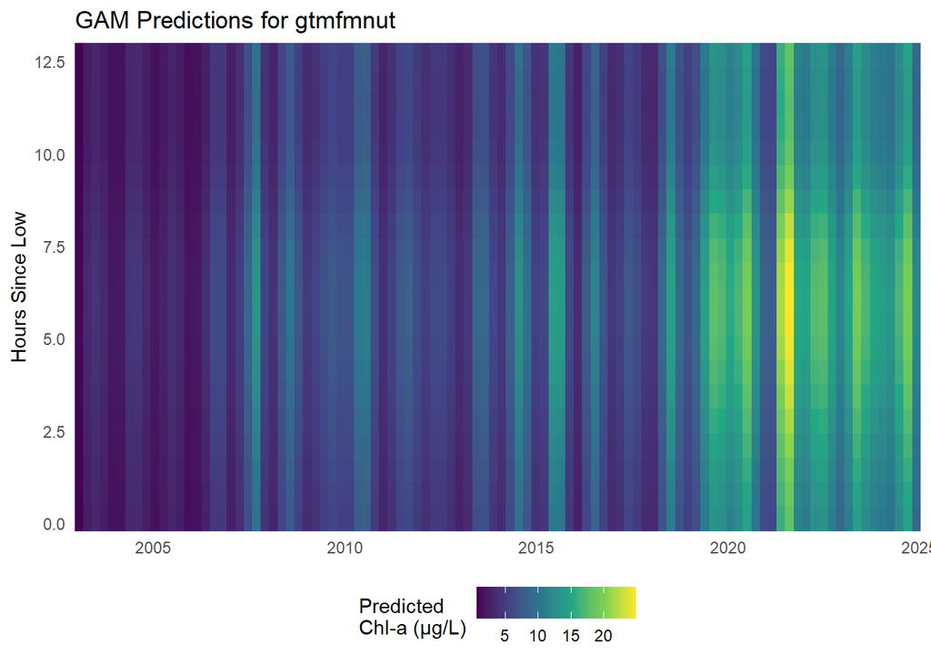

```r
toprd <- tibble(
    filter_method = unique(dat$filter_method)[1],
    lab = unique(dat$lab)[1]
  ) |>
  crossing(
    cont_year = seq(min(dat$cont_year), max(dat$cont_year), length.out = 100),
    hours_since_low = seq(min(dat$hours_since_low), max(dat$hours_since_low), length.out = 20)
  )

prds <- predict(m1b, newdata = toprd, type = "response")

toplo <- bind_cols(toprd, prds = prds)

ggplot(toplo, aes(x = cont_year, y = hours_since_low, fill = prds)) +
    geom_tile() +
    scale_x_continuous(expand = c(0, 0)) +
    scale_y_continuous(expand = c(0, 0)) +
    scale_fill_viridis_c() +
    theme_minimal() +
    theme(legend.position = 'bottom') +
    labs(title = paste("GAM Predictions for", sta),
         x = NULL,
         y = "Hours Since Low",
         fill = "Predicted\nChl-a (µg/L)"
    )
```

Actually, that plot is not that compelling, since the trends over time are much stronger than the tidal effects. Instead, we can look at the predictions over time for different tidal stages. This plot shows the marginal/conditional effects of each smoother and we can pull out times when the tide is at its lowest or highest to emphasize when these effects will be largest on chlorophyll, say 7 hours and 12 hours since low tide.

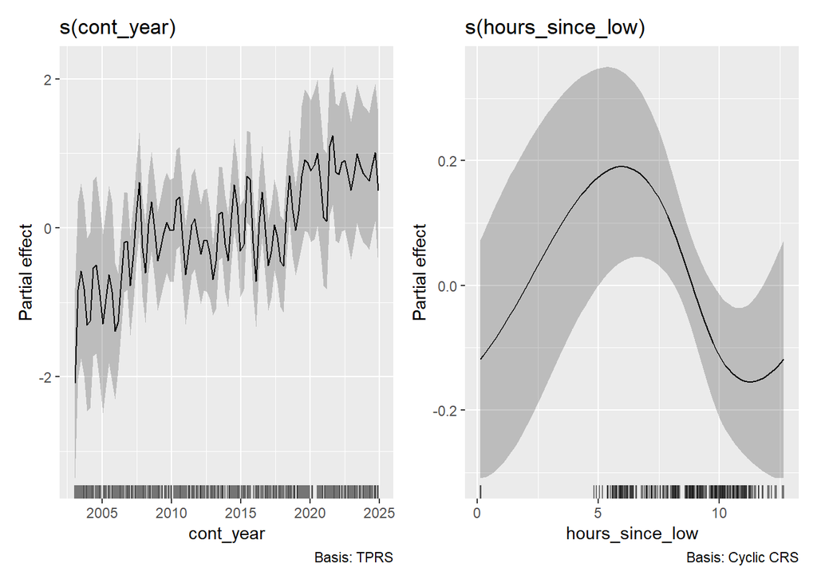

```r
draw(m1b)
```

Here’s the plot and I’m including the confidence intervals, which do overlap for these predictions because they account for the uncertainty across all predictors, not just hours since low tide. Time, filter method, and lab are also from the observed data for the prediction matrix to constrain the confidence intervals to reasonable values (e.g., filter method 0.3 um Field used at the start of the time series has very large CI if extrapolated to later in the time series).

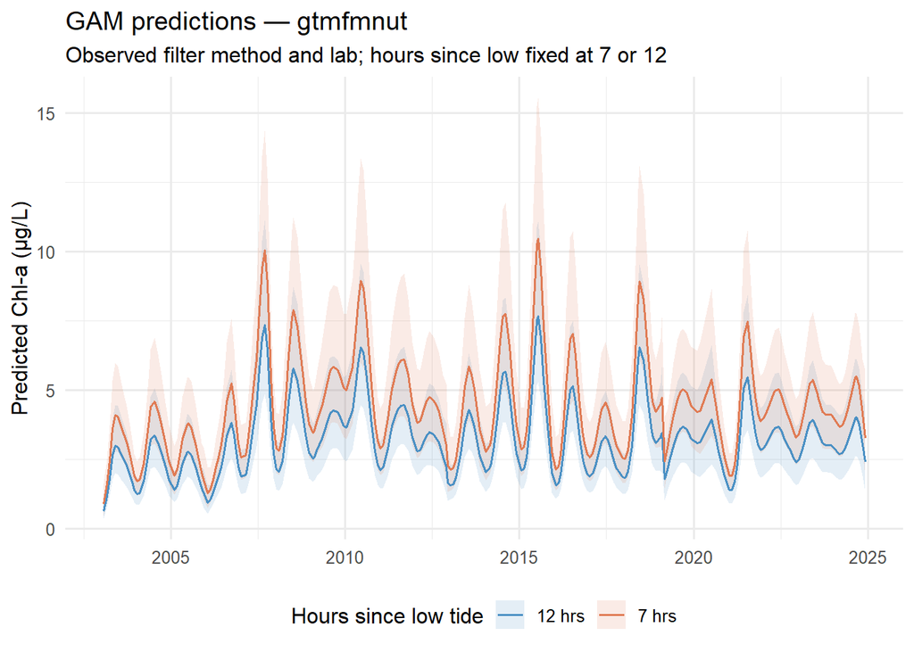

```r
dat_7  <- dat |> mutate(hours_since_low = 7)
dat_12 <- dat |> mutate(hours_since_low = 12)

get_preds <- function(newdat, hrs_label) {
  p <- predict(m1b, newdata = newdat, type = "link", se.fit = TRUE)
  newdat |>
    select(cont_year, filter_method, lab) |>
    mutate(
      hours_since_low = hrs_label,
      fit   = exp(p$fit),
      lower = exp(p$fit - 1.96 * p$se.fit),
      upper = exp(p$fit + 1.96 * p$se.fit)
    )
}

toplo <- bind_rows(
  get_preds(dat_7,  "7 hrs"),
  get_preds(dat_12, "12 hrs")
)

ggplot(toplo, aes(x = cont_year, color = hours_since_low, fill = hours_since_low)) +
  geom_ribbon(aes(ymin = lower, ymax = upper), alpha = 0.15, color = NA) +
  geom_line(aes(y = fit), linewidth = 0.6) +
  scale_color_manual(values = c("7 hrs" = "#E07B54", "12 hrs" = "#4A90C4")) +
  scale_fill_manual( values = c("7 hrs" = "#E07B54", "12 hrs" = "#4A90C4")) +
  theme_minimal(base_size = 12) +
  theme(legend.position = "bottom") +
  labs(
    title    = paste("GAM predictions —", sta),
    subtitle = "Observed filter method and lab; hours since low fixed at 7 or 12",
    x        = NULL,
    y        = "Predicted Chl-a (µg/L)",
    color    = "Hours since low tide",
    fill     = "Hours since low tide"
  )
```

In practice, you might just interpret the conditional effects plot above (second to last plot) to understand how hours since low tide affect chlorophyll. That plot shows the shows individual effect of the tide on chlorophyll across the time series. This is a more straightforward way to evaluate the tidal effects, though it does not capture how these effects might change over time.

## Half-baked thoughts

A couple things worth considering:

- To me, it’s more important to first develop a model that describes chlorophyll well as a first cut, otherwise interpreting the individual effects of the smoothers is not that meaningful.
- The Murphy method of choosing k is too conservative when you don’t have a seasonal smoother, so I would recommend using a higher value for k in the `cont_year` smoother. This will allow you to capture both the seasonal and inter-annual trends in chlorophyll better and then you can evaluate the effects of the filters and tide more meaningfully. You probably don’t need to set K as high as I did in these examples, but it’s probably worth experimenting with progrssively higher values until you see the jump and plateau in the R-squared and deviance explained.
- The `by` argument is not ideal for evaluating the effects of the filters because it fits separate smooths for each filter method, which confounds the filter effects with time. Instead, I would recommend including the filter method as a parametric term in the model and using a single smoother for time that includes all data. This way, you can evaluate the effects of the filters more directly while still capturing the temporal trends in chlorophyll.
- None of the content here speaks to model selection as you had in your powerpoint. I still think this is a valuable component of your analysis and I would repeat it with the higher k values to see how the model selection changes.